# DEM 7283 - Principal Components Analysis

Corey Sparks, PhD

21 March, 2022

This example illustrates the use of the method of *Principal Components Analysis* to form an index of overall health using data from the 2017 CDC Behavioral Risk Factor Surveillance System (BRFSS) SMART MSA data [Link](https://www.cdc.gov/brfss/smart/smart_2016.html) and an example of calcuating a place-based index of area deprivation.

Principal Components is a mathematical technique (not a statistical one!) based off the eigenvalue decomposition/singular value decomposition of a data matrix (or correlation/covariance matrix) [Link](http://en.wikipedia.org/wiki/Singular_value_decomposition). This technique re-represents a complicated data set (set of variables) in a simpler form, where the information in the original variables is now represented by fewer *components*, which represent the majority (we hope!!) of the variance in the original data.

This is known as a variable reduction strategy. It is also used commonly to form indices in the behavioral/social sciences. It is closely related to factor analysis [Link](http://en.wikipedia.org/wiki/Factor_analysis), and indeed the initial solution of factor analysis is often the exact same as the PCA solution. PCA preserves the orthogonal nature of the components, while factor analysis can violate this assumption.

### PCA in formulas

If we have a series of variables, called
$$X$$
, with
$$X
= \left [ x_1, x_2, ..., x_k \right ]$$
, and we have the Pearson correlation matrix between these variables,
$$R$$
, with

$$R = \begin{bmatrix}
r_{11} & r_{12} & \cdots & r_{1k} \\
r_{21}& r_{22} & \ddots & r_{2k}\\
\vdots & \cdots & \vdots & \vdots \\
r_{k1} & \cdots & \cdots & r_{kk}\\
\end{bmatrix}$$

The singular value decomposition of
$$R$$
is
$${R a}
= \lambda a$$

where $\lambda$’s are the *eigenvalues* of **R** and *a* are the *eigenvectors* of R.

These values are found by solving this equation for the eigenvalues and corresponding vectors of **R**, by :

$$( R - \lambda I )a = 0$$

if the determinant of $R-\lambda I$ is not 0, then there will be k solutions (for each of the k original variables) to the equation, or k eigenvalues, and k accompanying eigenvectors.

The eigenvalues of R are ranked, with the first being the largest and the kth being the smallest. So, we will have $\lambda_1 >\lambda_2 > \cdots >\lambda_k$

Each eigenvalue accounts for a proportion of all the variation within the matrix, and we can see this proportion by:

% variance explained= $\frac{\lambda_i}{\sum_i \lambda_i}$

The eigenvectors **a** will each be *orthogonal*, or uncorrelated with each other, and will be linear combinations of the original k variables.

These two items form what is known as the singular value (or eigenvalue) decomposition of a square matrix, and when that matrix is a correlation matrix, this is called **Principal Components Analysis** or PCA. The idea is that we have a new set of uncorrelated variables (due to the orthogonal nature of the eigenvectors), or *components* that summarize the information in the original k variables in a smaller number of components. For example, we may have had 10 variables originally, that we thought measured “health”, but after doing a PCA, we may have three components that summarize 75% of the information in these original 10 variables, so we have a simpler set of variables. Moreover, each component now corresponds to a unique and independent subset of the information in the original 10 variables.

### Variable loadings

Each new component has an eigenvector, that we call a *loading vector*. We can see how each variable is related to the new component by examining the loading for each component. These can be thought of in a very similar way as standardized regression coefficients. Large positive values indicate positive association of that variable with the component, large negative values, the opposite, and values close to 0 indicate that a particular variable doesn’t contribute to that component. There are no tests, and this can be **very subjective** in terms of interpretations.

### Using this in research

So, this formalism is nice, but what does this boil down to in terms of research. Well, that depends on what you’re looking for. Many people will use PCA to summarize information on lots of variables that may be correlated, in the hopes of finding a smaller subset of variables that represent some underlying latent trait that you want to measure. Often times, people will use this method to construct an *index* for something. While there are lots of ways to do an index, PCA is advantageous, because it acknowledges the correlation among variables.

For example [Sharkey and Horel, 2008](http://jn.nutrition.org/content/138/3/620.full.pdf+html) use this method to construct an index of socioeconomic deprivation for census tracts, and [Messer et al, 2006](https://link.springer.com/article/10.1007/s11524-006-9094-x) also use this method for a deprivation index in the context of low birth weight outcomes.

### General rules

1. Always use z-scored variables when doing a PCA -> scale is very important, as we want correlations going in, not covariances.
2. Code variables in a common direction, so that larger values of all variables indicated the same directionality. E.g. higher values of “health” indicate better health, etc.
3. If the first eigenvalue is less than 1, your PCA isn’t doing anything for you, it isn’t finding any correlated information among your variables
4. Have a look at how much variation your component is summarizing, in aggregate data it will tend to be more than in individual level survey data
5. Doing scatter plots of the first few PC’s can often be informative for finding underlying groups in your data, as people tend to cluster together in multidimensional space
6. You can use the PCs in a regression model if you’ve had problems with multicollinearity among variables. This is called Principal component regression.

```r
library(car)
library(stargazer)
library(survey)
library(ggplot2)
library(pander)
library(dplyr)
library(knitr)
library(factoextra)
library(FactoMineR)
```

```r
brfss20<- readRDS(url("https://github.com/coreysparks/DEM7283/blob/master/data/brfss20sm.rds?raw=true"))

names(brfss20) <- tolower(gsub(pattern = "_",replacement =  "",x =  names(brfss20)))
```

### Recode variables

```r
#Healthy days
brfss20$healthdays<-Recode(brfss20$physhlth, recodes = "88=0; 77=NA; 99=NA")

#Healthy mental health days
brfss20$healthmdays<-Recode(brfss20$menthlth, recodes = "88=0; 77=NA; 99=NA")

brfss20$health<-Recode(brfss20$genhlth, recodes="4:5=1; 1:3=0; else=NA")

#race/ethnicity
brfss20$black<-Recode(brfss20$racegr3, recodes="2=1; 9=NA; else=0")
brfss20$white<-Recode(brfss20$racegr3, recodes="1=1; 9=NA; else=0")
brfss20$other<-Recode(brfss20$racegr3, recodes="3:4=1; 9=NA; else=0")
brfss20$hispanic<-Recode(brfss20$racegr3, recodes="5=1; 9=NA; else=0")

brfss20$race_eth<-Recode(brfss20$racegr3,
recodes="1='nhwhite'; 2='nh black'; 3='nh other';4='nh multirace'; 5='hispanic'; else=NA",
as.factor = T)
brfss20$race_eth<-relevel(brfss20$race_eth, ref = "nhwhite")

#insurance
brfss20$ins<-Recode(brfss20$hlthpln1, recodes ="7:9=NA; 1=1;2=0")

#income grouping
brfss20$inc<-ifelse(brfss20$incomg==9, NA, brfss20$incomg)

#education level
brfss20$educ<-Recode(brfss20$educa,
recodes="1:2='0Prim'; 3='1somehs'; 4='2hsgrad'; 5='3somecol'; 6='4colgrad';9=NA",
as.factor=T)

brfss20$educ<-relevel(brfss20$educ, ref='2hsgrad')

#employment
brfss20$employ<-Recode(brfss20$employ1,
recodes="1:2='Employed'; 2:6='nilf'; 7='retired'; 8='unable'; else=NA",
as.factor=T)

brfss20$employ<-relevel(brfss20$employ, ref='Employed')

#marital status
brfss20$marst<-Recode(brfss20$marital,
recodes="1='married'; 2='divorced'; 3='widowed'; 4='separated'; 5='nm';6='cohab'; else=NA",
as.factor=T)

brfss20$marst<-relevel(brfss20$marst, ref='married')

#BMI, in the brfss20a the bmi variable has 2 implied decimal places,
#so we must divide by 100 to get real bmi's

brfss20$bmi<-brfss20$bmi5/100

#smoking currently
brfss20$smoke<-Recode(brfss20$smoker3,
recodes="1:2=1; 3:4=0; else=NA")

brfss20$checkup<-Recode(brfss20$checkup1, recodes = "1:2 = 1; 3:4=0; 8=0; else=NA")
#brfss20$hbp<-Recode(brfss20$, recodes = "1= 1; 2:4=0; else=NA")

brfss20$heart<-Recode(brfss20$cvdcrhd4, recodes = "1= 1; 2=0; else=NA")
brfss20$ast<-Recode(brfss20$asthma3, recodes = "1= 1; 2:4=0; else=NA")
```

### Analysis

Now we prepare to fit the survey corrected model. Here I just get the names of the variables that i will use, this keeps the size of things down, in terms of memory used

```r
brfss20b<-brfss20%>%
  filter(complete.cases(mmsawt, ststr, ageg, race_eth,educ, healthdays, healthmdays, smoke, bmi, health,ins, checkup,   heart, ast))%>%
  select(mmsawt, ststr, ageg, race_eth,educ, healthdays, healthmdays, smoke, bmi, health,ins, checkup,  heart, ast)#%>%
#  mutate_at(vars(healthdays, healthmdays, smoke, bmi, badhealth,ins, checkup,  heart, ast), scale)

samps <- sample(1:dim(brfss20b)[1], size = 10000, replace = FALSE)
brfss20b<- brfss20b[samps,]
```

### PCA using `FactoMineR`

```r
brfss.pc<-PCA(brfss20b[, c(6:14)], #columns 6:14 are my variables, yours will be different
              scale.unit = T, #center the variables
              graph = F)
```

```r
eigenvalues  <- brfss.pc$eig
head(eigenvalues[, 1:2])
```

```
##        eigenvalue percentage of variance
## comp 1  1.9222693              21.358548
## comp 2  1.3271317              14.745908
## comp 3  1.0118524              11.242805
## comp 4  0.9843406              10.937118
## comp 5  0.8964208               9.960231
## comp 6  0.8828071               9.808968
```

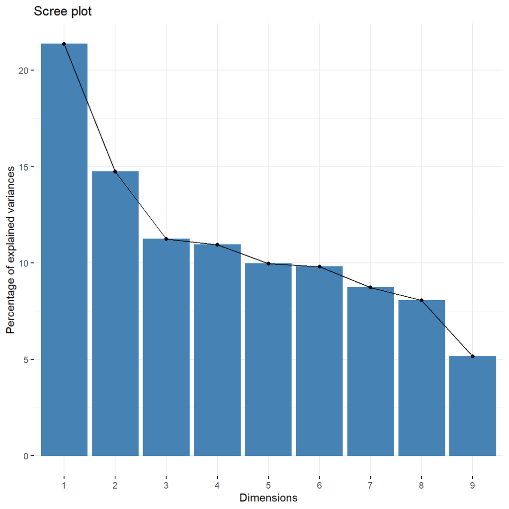

```r
fviz_screeplot(brfss.pc, ncp=10)
```

Summary of eignevalues and variance explained

```r
#Request some basic summaries of the PCA analysis option(digits=3)
brfss.pc$var
```

```
## $coord
##                   Dim.1       Dim.2        Dim.3       Dim.4       Dim.5
## healthdays   0.78854004  0.06694546 -0.123613834  0.04248942  0.09146881
## healthmdays  0.55212495 -0.22998785  0.130365662  0.38518527  0.10274654
## smoke        0.27427275 -0.42174443 -0.267999988  0.31538618  0.16508835
## bmi          0.31760109  0.08009608  0.438280360 -0.62618304  0.41986025
## health       0.78082876  0.06081079 -0.115308054 -0.07874565  0.05944627
## ins         -0.02063360  0.69049617  0.013401996  0.38064022  0.12220508
## checkup      0.04182413  0.72546597  0.009571518  0.15258495  0.17764172
## heart        0.32510856  0.27867084 -0.504328741 -0.37686889 -0.51748706
## ast          0.31933033  0.03210346  0.669140140  0.16184493 -0.59677737
##
## $cor
##                   Dim.1       Dim.2        Dim.3       Dim.4       Dim.5
## healthdays   0.78854004  0.06694546 -0.123613834  0.04248942  0.09146881
## healthmdays  0.55212495 -0.22998785  0.130365662  0.38518527  0.10274654
## smoke        0.27427275 -0.42174443 -0.267999988  0.31538618  0.16508835
## bmi          0.31760109  0.08009608  0.438280360 -0.62618304  0.41986025
## health       0.78082876  0.06081079 -0.115308054 -0.07874565  0.05944627
## ins         -0.02063360  0.69049617  0.013401996  0.38064022  0.12220508
## checkup      0.04182413  0.72546597  0.009571518  0.15258495  0.17764172
## heart        0.32510856  0.27867084 -0.504328741 -0.37686889 -0.51748706
## ast          0.31933033  0.03210346  0.669140140  0.16184493 -0.59677737
##
## $cos2
##                    Dim.1       Dim.2        Dim.3       Dim.4       Dim.5
## healthdays  0.6217953894 0.004481695 1.528038e-02 0.001805350 0.008366543
## healthmdays 0.3048419553 0.052894412 1.699521e-02 0.148367689 0.010556852
## smoke       0.0752255394 0.177868361 7.182399e-02 0.099468442 0.027254165
## bmi         0.1008704498 0.006415382 1.920897e-01 0.392105198 0.176282627
## health      0.6096935542 0.003697952 1.329595e-02 0.006200877 0.003533859
## ins         0.0004257457 0.476784964 1.796135e-04 0.144886980 0.014934083
## checkup     0.0017492580 0.526300872 9.161396e-05 0.023282165 0.031556582
## heart       0.1056955757 0.077657439 2.543475e-01 0.142030158 0.267792859
## ast         0.1019718625 0.001030632 4.477485e-01 0.026193782 0.356143228
##
## $contrib
##                   Dim.1       Dim.2        Dim.3      Dim.4      Dim.5
## healthdays  32.34694430  0.33769779  1.510139164  0.1834071  0.9333276
## healthmdays 15.85844140  3.98561891  1.679613068 15.0727993  1.1776670
## smoke        3.91337146 13.40246485  7.098267625 10.1050834  3.0403316
## bmi          5.24746706  0.48340208 18.983961259 39.8342993 19.6651648
## health      31.71738449  0.27864241  1.314020396  0.6299524  0.3942188
## ins          0.02214807 35.92597185  0.017750959 14.7191911  1.6659679
## checkup      0.09099963 39.65701885  0.009054084  2.3652549  3.5202867
## heart        5.49847901  5.85152464 25.136815477 14.4289641 29.8735660
## ast          5.30476458  0.07765862 44.250377968  2.6610485 39.7294696
```

Examine eignevectors/loading vectors

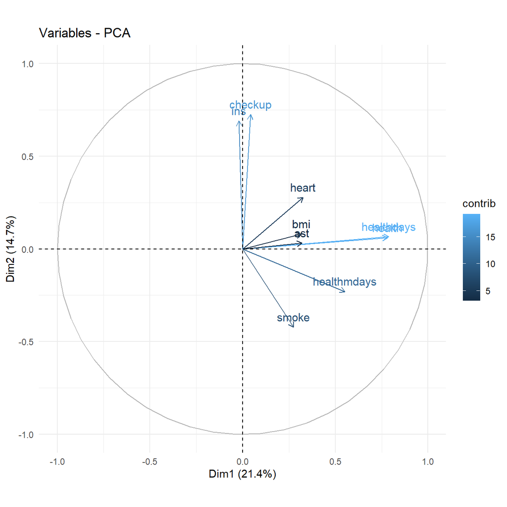

```r
fviz_pca_var(brfss.pc,
            col.var="contrib")+
  theme_minimal()
```

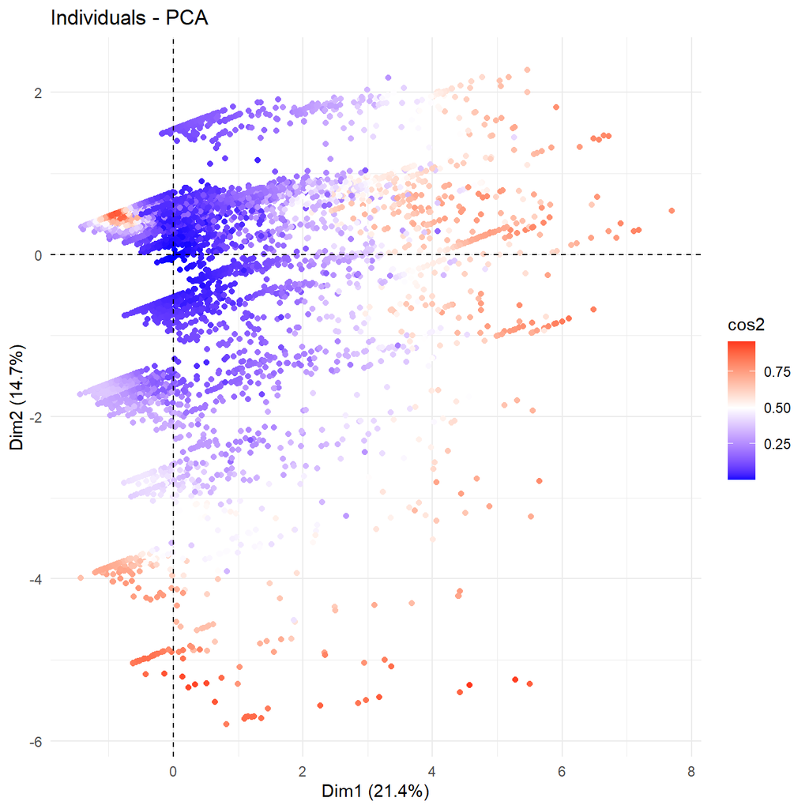

```r
fviz_pca_ind(brfss.pc,
             label="none",
             col.ind="cos2" )+
  scale_color_gradient2(low="blue",
                        mid="white",
                      high="red",
                      midpoint = .5)+
  theme_minimal()
```

### Understanding the meaning of PC dimensions.

Some tools that allow for better understanding of the components are: - Correlation of each variable with each PC - Rank correlations from lowest to highest

```r
desc <- dimdesc(brfss.pc)
desc$Dim.1
```

```
## $quanti
##             correlation       p.value
## healthdays   0.78854004  0.000000e+00
## health       0.78082876  0.000000e+00
## healthmdays  0.55212495  0.000000e+00
## heart        0.32510856 7.328054e-245
## ast          0.31933033 7.830383e-236
## bmi          0.31760109 3.607762e-233
## smoke        0.27427275 4.746340e-172
## checkup      0.04182413  2.867762e-05
## ins         -0.02063360  3.908203e-02
##
## attr(,"class")
## [1] "condes" "list"
```

```r
desc$Dim.2
```

```
## $quanti
##             correlation       p.value
## checkup      0.72546597  0.000000e+00
## ins          0.69049617  0.000000e+00
## heart        0.27867084 8.968539e-178
## bmi          0.08009608  1.044646e-15
## healthdays   0.06694546  2.066764e-11
## health       0.06081079  1.158018e-09
## ast          0.03210346  1.323788e-03
## healthmdays -0.22998785 3.589957e-120
## smoke       -0.42174443  0.000000e+00
##
## attr(,"class")
## [1] "condes" "list"
```

### Using the Principal Components

Next, I will use the PC’s we just generated in an analysis. This is often done to make an outcome variable for further analysis or to make an index to be used as a predictor variable(s).

```r
#Make the survey design object
brfss20b$pc1 <- brfss.pc$ind$coord[, 1]

options(survey.lonely.psu = "adjust")
des<-svydesign(ids=~1,
               strata=~ststr,
               weights=~mmsawt,
               data=brfss20b)
```

The first analysis will look at variation in my health index across age, and education level:

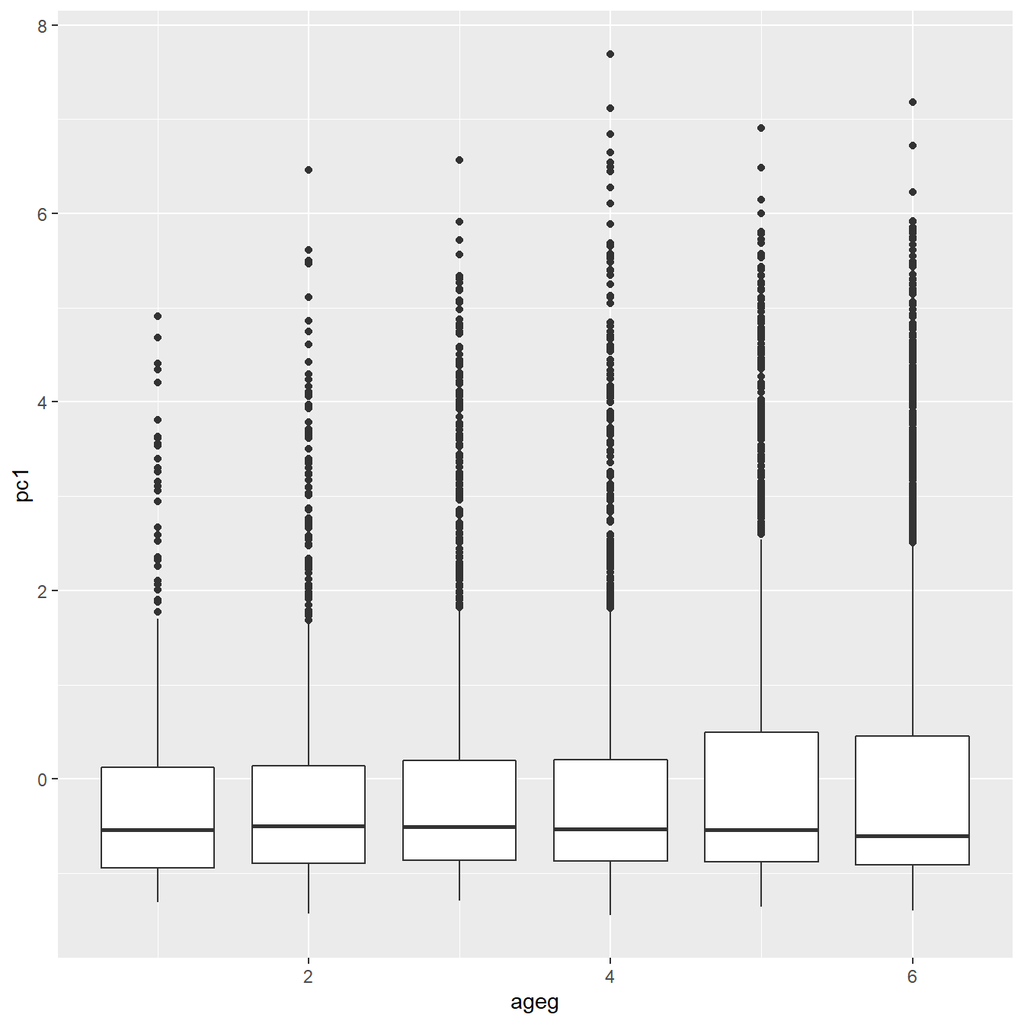

```r
library(ggplot2)
ggplot(aes(x=ageg, y=pc1, group=ageg),
       data=brfss20b)+
  geom_boxplot()
```

```r
brfss20b$educ<- forcats::fct_relevel(brfss20b$educ, .x =  c("0Prim",  "1somehs","2hsgrad", "3somecol", "4colgrad"))
```

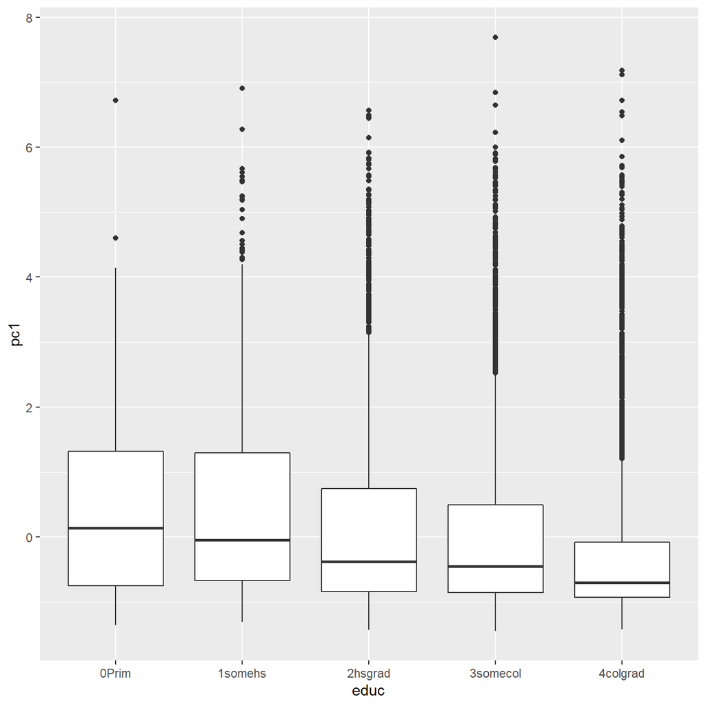

```r
ggplot(aes(x=educ, y=pc1),
       data=brfss20b)+
  geom_boxplot()
```

The age plot is nice, and really shows that older ages have higher values for our health index variable, which confirms our interpretation that higher values of the index are “not good”

```r
fit.1<-svyglm(pc1~factor(ageg)+educ+(race_eth),
              des,
              family=gaussian)
summary(fit.1)
```

```
##
## Call:
## svyglm(formula = pc1 ~ factor(ageg) + educ + (race_eth), design = des,
##     family = gaussian)
##
## Survey design:
## svydesign(ids = ~1, strata = ~ststr, weights = ~mmsawt, data = brfss20b)
##
## Coefficients:
##                      Estimate Std. Error t value Pr(>|t|)
## (Intercept)          -0.24467    0.09139  -2.677  0.00744 **
## factor(ageg)2         0.11989    0.08559   1.401  0.16131
## factor(ageg)3         0.30951    0.09964   3.106  0.00190 **
## factor(ageg)4         0.42068    0.11042   3.810  0.00014 ***
## factor(ageg)5         0.44799    0.11864   3.776  0.00016 ***
## factor(ageg)6         0.39259    0.09261   4.239 2.26e-05 ***
## educ0Prim             0.21914    0.16235   1.350  0.17712
## educ1somehs           0.44409    0.19803   2.243  0.02495 *
## educ3somecol         -0.01988    0.08153  -0.244  0.80734
## educ4colgrad         -0.43468    0.06578  -6.608 4.11e-11 ***
## race_ethhispanic      0.03840    0.10986   0.350  0.72666
## race_ethnh black      0.08856    0.07911   1.120  0.26292
## race_ethnh multirace  0.35430    0.22576   1.569  0.11661
## race_ethnh other      0.06777    0.17493   0.387  0.69847
## ---
## Signif. codes:  0 '***' 0.001 '**' 0.01 '*' 0.05 '.' 0.1 ' ' 1
##
## (Dispersion parameter for gaussian family taken to be 1.695664)
##
## Number of Fisher Scoring iterations: 2
```

So, overall, the index increases across age, and decreases with higher education. Among the 10,000 sampled individuals, there is no variation between the race/ethnic groups.

### Aggregate data example - Indices for Places

This is an example from a paper some former students and I did at the 2014 Applied Demography conference entitled “Spatial accessibility to food sources in Alamo Area Council of Governments (AACOG)” where, we examined factors influencing whether or not a census tract was a food desert in the area surrounding San Antonio. We used the index from the Sharkey paper above.

```r
library(sf)
sp<-st_read(dsn = "../data", layer = "shp2_nm")
```

```r
nosp <- sp
st_geometry(nosp)<- NULL

pc_shark <- PCA(nosp[, c("punemp", "pprsnsp", "p25plsl","gt1prrm","pubasst","phwoveh","phwophn" )],
                scale.unit = T, #center the variables
              graph = F)


summary(pc_shark)
```

```
##
## Call:
## PCA(X = nosp[, c("punemp", "pprsnsp", "p25plsl", "gt1prrm", "pubasst",
##      "phwoveh", "phwophn")], scale.unit = T, graph = F)
##
##
## Eigenvalues
##                        Dim.1   Dim.2   Dim.3   Dim.4   Dim.5   Dim.6   Dim.7
## Variance               4.211   0.746   0.672   0.493   0.397   0.249   0.232
## % of var.             60.158  10.660   9.607   7.036   5.666   3.562   3.311
## Cumulative % of var.  60.158  70.818  80.425  87.461  93.127  96.689 100.000
##
## Individuals (the 10 first)
##             Dist    Dim.1    ctr   cos2    Dim.2    ctr   cos2    Dim.3    ctr
## 1       |  1.854 |  0.499  0.013  0.072 | -0.829  0.198  0.200 | -1.263  0.509
## 2       |  1.287 |  0.367  0.007  0.081 |  0.105  0.003  0.007 | -0.019  0.000
## 3       |  1.346 | -0.289  0.004  0.046 | -0.807  0.187  0.359 |  0.225  0.016
## 4       |  1.675 | -0.934  0.044  0.311 |  0.408  0.048  0.059 | -0.865  0.239
## 5       |  1.921 |  1.418  0.102  0.544 |  0.269  0.021  0.020 | -0.807  0.208
## 6       |  1.034 | -0.144  0.001  0.019 | -0.052  0.001  0.002 |  0.638  0.130
## 7       |  1.207 | -0.240  0.003  0.040 |  0.827  0.197  0.470 |  0.237  0.018
## 8       |  0.970 | -0.361  0.007  0.138 | -0.213  0.013  0.048 | -0.366  0.043
## 9       |  1.678 | -1.608  0.132  0.918 |  0.190  0.010  0.013 | -0.308  0.030
## 10      |  1.953 | -0.995  0.050  0.260 |  0.247  0.018  0.016 | -0.674  0.145
##           cos2
## 1        0.464 |
## 2        0.000 |
## 3        0.028 |
## 4        0.267 |
## 5        0.176 |
## 6        0.381 |
## 7        0.039 |
## 8        0.142 |
## 9        0.034 |
## 10       0.119 |
##
## Variables
##            Dim.1    ctr   cos2    Dim.2    ctr   cos2    Dim.3    ctr   cos2
## punemp  |  0.734 12.806  0.539 |  0.392 20.557  0.153 | -0.031  0.140  0.001 |
## pprsnsp |  0.877 18.251  0.769 | -0.057  0.430  0.003 |  0.051  0.394  0.003 |
## p25plsl |  0.883 18.495  0.779 | -0.089  1.065  0.008 | -0.184  5.044  0.034 |
## gt1prrm |  0.715 12.138  0.511 |  0.031  0.128  0.001 | -0.634 59.696  0.401 |
## pubasst |  0.652 10.108  0.426 |  0.553 40.916  0.305 |  0.324 15.629  0.105 |
## phwoveh |  0.805 15.404  0.649 | -0.255  8.682  0.065 |  0.311 14.351  0.097 |
## phwophn |  0.734 12.799  0.539 | -0.459 28.223  0.211 |  0.179  4.746  0.032 |
```

```r
desc <- dimdesc(pc_shark)
desc$Dim.1
```

```
## $quanti
##         correlation       p.value
## p25plsl   0.8825142 3.965782e-154
## pprsnsp   0.8766716 1.506769e-149
## phwoveh   0.8054014 1.851190e-107
## punemp    0.7343446  4.198619e-80
## phwophn   0.7341369  4.896421e-80
## gt1prrm   0.7149446  4.007665e-74
## pubasst   0.6524212  7.604231e-58
##
## attr(,"class")
## [1] "condes" "list"
```

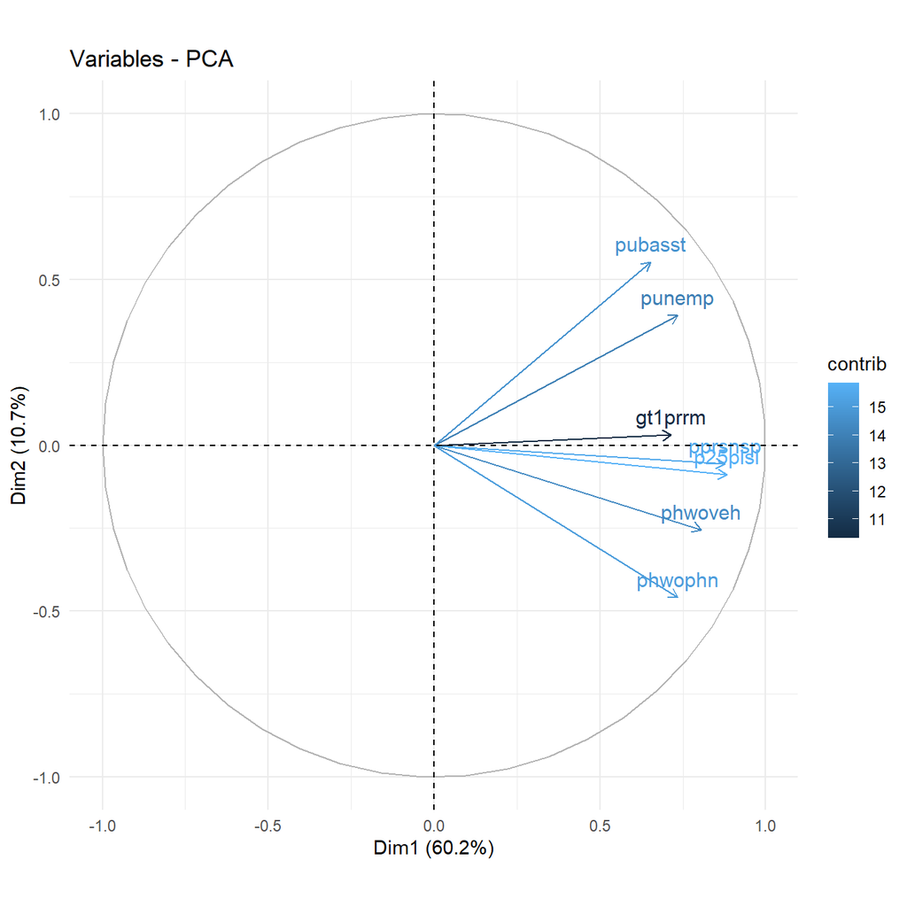

```r
fviz_pca_var(pc_shark,
            col.var="contrib")+
  theme_minimal()
```

```r
# Here I reverse the direction of the index by multiplying by -1
sp$sharkeyindex<- pc_shark$ind$coord[,1]
```

```r
fit<-glm(LILAT_1A1~scale(interct)+Rural+sharkeyindex,family=binomial, sp)
summary(fit)
```

```
##
## Call:
## glm(formula = LILAT_1A1 ~ scale(interct) + Rural + sharkeyindex,
##     family = binomial, data = sp)
##
## Deviance Residuals:
##     Min       1Q   Median       3Q      Max
## -1.9708  -0.5811  -0.4086  -0.2650   2.4890
##
## Coefficients:
##                Estimate Std. Error z value Pr(>|z|)
## (Intercept)    -1.39995    0.15204  -9.208  < 2e-16 ***
## scale(interct)  0.17927    0.20866   0.859   0.3902
## Rural          -1.13827    0.46219  -2.463   0.0138 *
## sharkeyindex    0.57771    0.09846   5.868 4.42e-09 ***
## ---
## Signif. codes:  0 '***' 0.001 '**' 0.01 '*' 0.05 '.' 0.1 ' ' 1
##
## (Dispersion parameter for binomial family taken to be 1)
##
##     Null deviance: 484.62  on 465  degrees of freedom
## Residual deviance: 384.29  on 462  degrees of freedom
## AIC: 392.29
##
## Number of Fisher Scoring iterations: 5
```

Map estimates of fitted probability of food desert

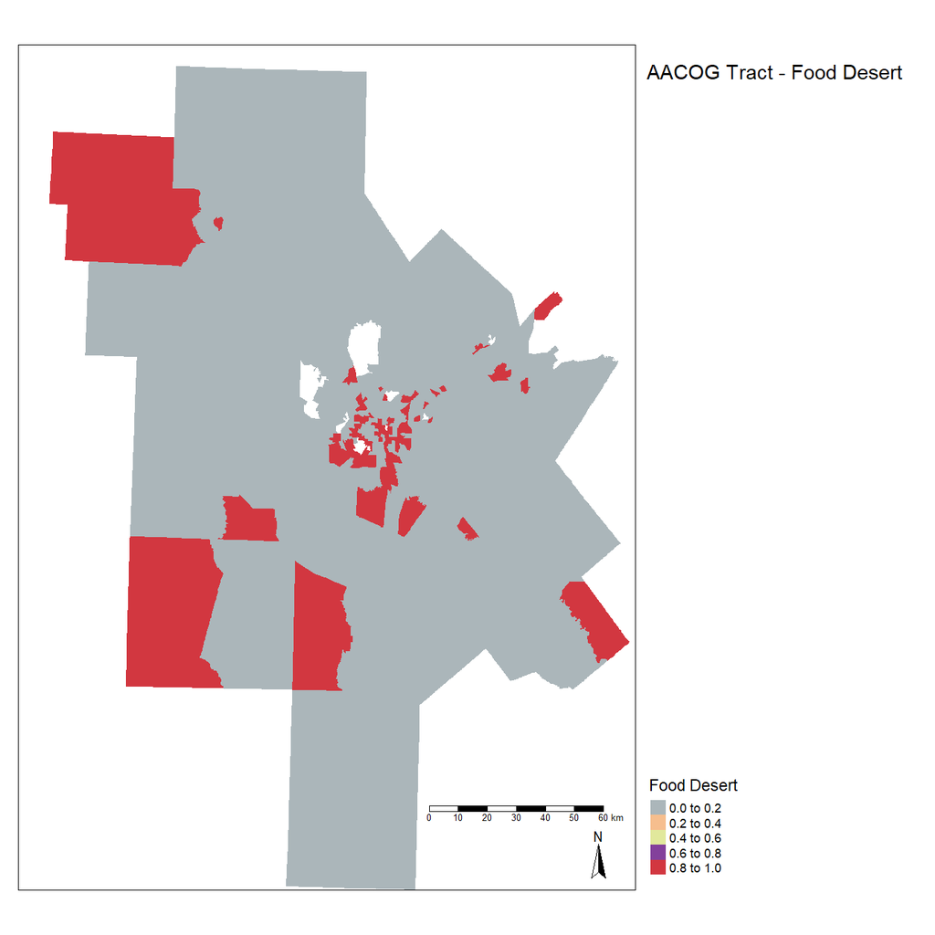

```r
sp$fitted<-fit$fitted.values

library(tmap)
library(tmaptools)

m0<-tm_shape(sp)+
  tm_polygons("LILAT_1A1", title="Food Desert", palette="Accent",  border.col = NULL)+
  tm_format("World", title="AACOG Tract - Food Desert", legend.outside=T)+
  tm_scale_bar()+
  tm_compass()


m1<-tm_shape(sp)+
  tm_polygons("fitted", title="Pr Food Desert", palette="Blues", style="quantile", border.col = NULL)+
  tm_format("World", title="AACOG Tract - Probability of Food Desert", legend.outside=T)+
  tm_scale_bar()+
  tm_compass()

m2<-tm_shape(sp)+
  tm_polygons("sharkeyindex", title="Risk Index", palette="Greens", style="fisher",border.col = NULL)+
  tm_format("World", title="AACOG Tract - Risk Index", legend.outside=T)+
   tm_scale_bar()+
  tm_compass()

m0
```

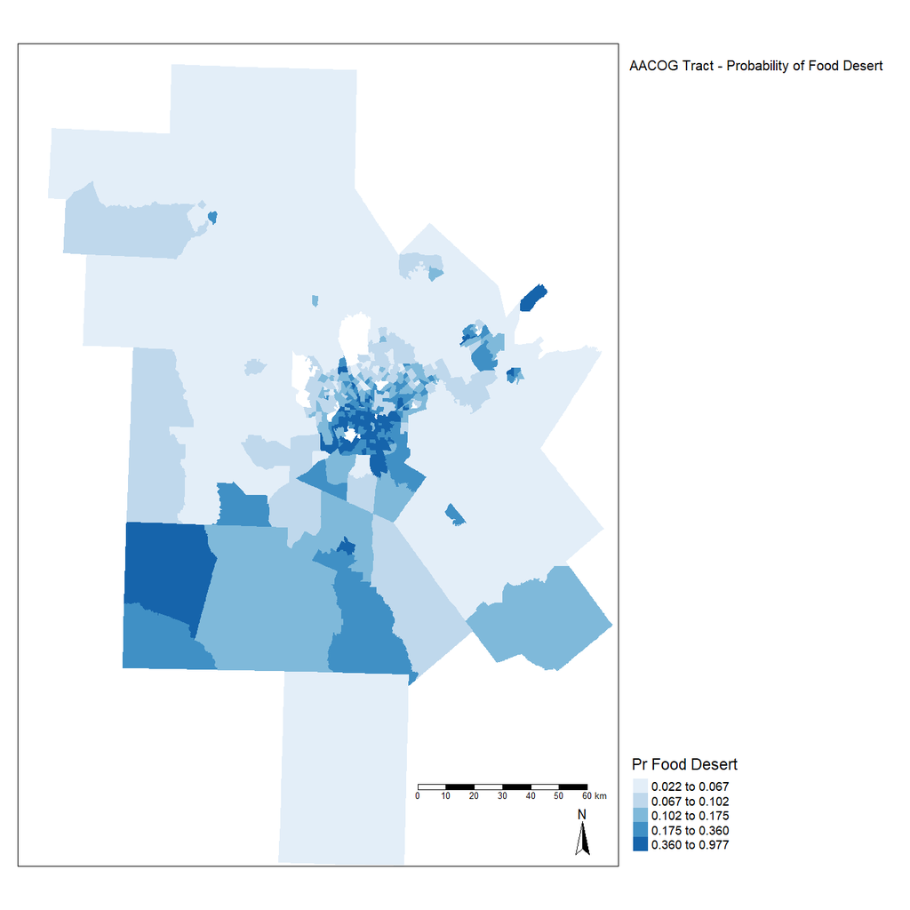

```r
m1
```

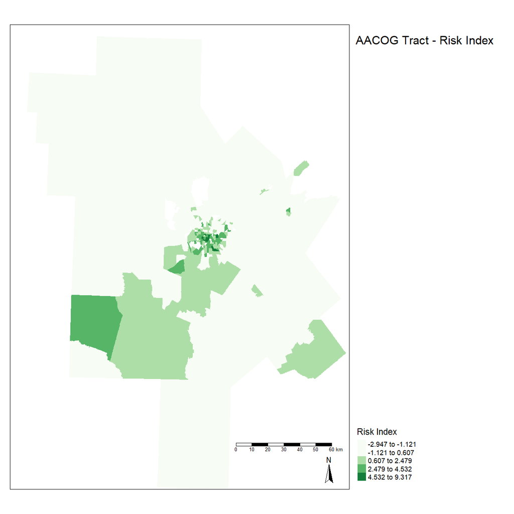

```r
m2
```

So, in areas that had higher values of the index, the odds of being a food desert were also higher. This was offset by being in a rural area, where the odds of being a food desert were lower.